# Klasterizavimas

Domantas Gudas

2026-04-03

# 1 Duomenų paruošimas

# 2 Optimalaus klasterių skaičiaus paieška

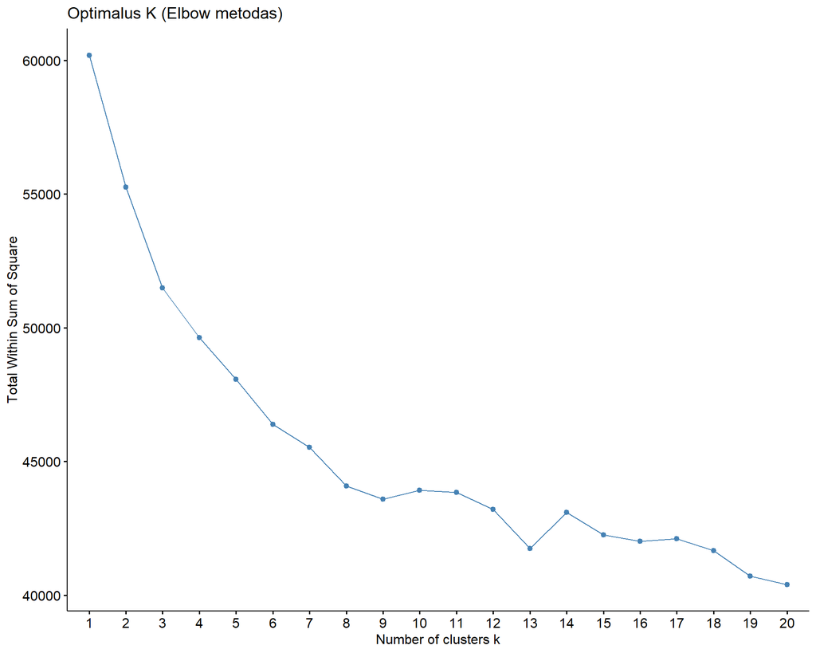

Renkamės kiekį klasterių pagal alkūnės metodą, maždaug kur jau nustoja sparčiai žemėti tiesė grafike, aplink $K=8$.

# 3 Klasterizavimas (CLARA)

Suklasterizuojame.

# 4 Rezultatų analizė ir vizualizacija

## 4.1 Mirtingumo suvestinė

**Klasterių analizės suvestinė**

| cluster | N | Vyrų dalis (%) | Amžiaus Mediana | Amžiaus Vidurkis | Mirtys | Mirtingumas (%) | Status |
| --- | --- | --- | --- | --- | --- | --- | --- |
| 1 | 18001 | 69.9 | 82 | 80.5 | 10117 | 56.2 % | ⚠️ High Risk |
| 2 | 26218 | 70.2 | 74 | 72.2 | 4837 | 18.45 % | Moderate |
| 3 | 22396 | 55.7 | 76 | 74.3 | 5546 | 24.76 % | Moderate |
| 4 | 27545 | 50.0 | 68 | 67.7 | 4021 | 14.6 % | Moderate |
| 5 | 30058 | 62.4 | 74 | 71.7 | 8853 | 29.45 % | Moderate |
| 6 | 14148 | 60.7 | 75 | 73.6 | 5103 | 36.07 % | ⚠️ High Risk |
| 7 | 11374 | 50.4 | 79 | 77.2 | 5455 | 47.96 % | ⚠️ High Risk |
| 8 | 2504 | 72.5 | 65 | 65.8 | 289 | 11.54 % | Moderate |

1, 6 ir 7 klasteriai demonstruoja “kritinį” mirtingumą (>30%). Mirtingumas - ar žmogus mirė stebėtu laikotarpiu dėl bet kokios priežasties.

Ypač išsiskiria 1-as klasteris, kuriame mirtingumas siekia net 56.2%. Atkreiptinas dėmesys, kad šios grupės amžiaus vidurkis (~80 m.) yra aukščiausias, todėl tai reprezentuoja vyresnio amžiaus pacientus.

## 4.2 Vizualus palyginimas: Mirtingumas vs Amžius

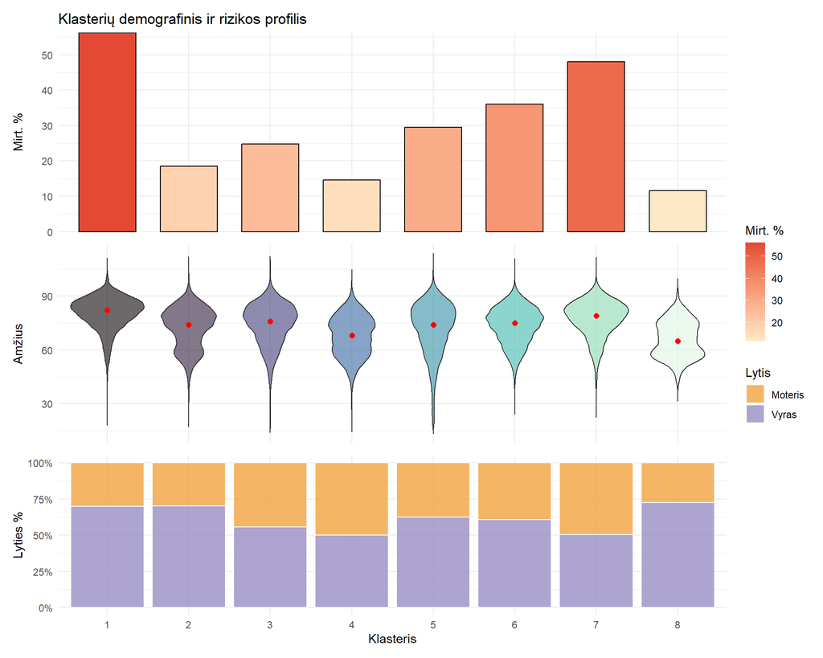

Smuiko grafiko „pilvas“ (plačiausia vieta) rodo, kur susikoncentravusi didžiausia dalis žmonių. Matome, kad pirmame klasteryje susikaupimas yra ties 80 metų riba. Siauros vietos nurodo, kad duomenų yra mažai.

## 4.3 Klasterių ligų profiliai (Heatmap)

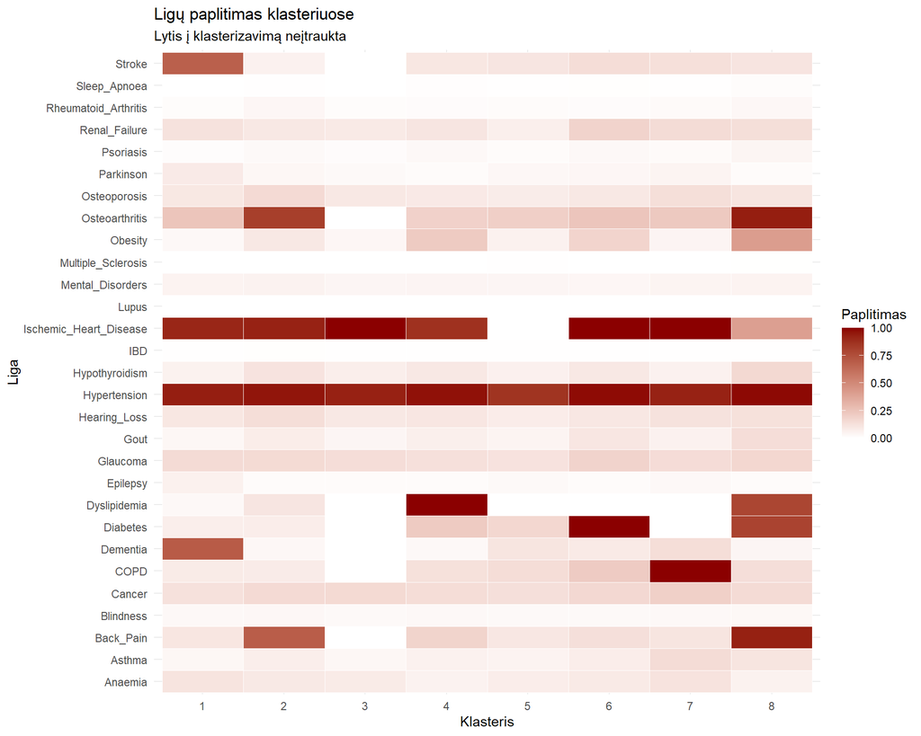

## 4.4 Klasteriai

### 4.4.1 Pirmas klasteris

Top 10 ligų 1-ame klasteryje

| cluster | Liga | Paplitimas Klasteryje |
| --- | --- | --- |
| 1 | Hypertension | 93.6 % |
| 1 | Ischemic_Heart_Disease | 91.1 % |
| 1 | Dementia | 70.1 % |
| 1 | Stroke | 68 % |
| 1 | Osteoarthritis | 24.3 % |
| 1 | Glaucoma | 14.7 % |
| 1 | Cancer | 12.5 % |
| 1 | Renal_Failure | 12 % |
| 1 | Anaemia | 11.3 % |
| 1 | Back_Pain | 10.5 % |

### 4.4.2 Antras klasteris

Top 10 ligų 2-ame klasteryje

| cluster | Liga | Paplitimas Klasteryje |
| --- | --- | --- |
| 2 | Hypertension | 96.1 % |
| 2 | Ischemic_Heart_Disease | 92.3 % |
| 2 | Osteoarthritis | 82 % |
| 2 | Back_Pain | 69.2 % |
| 2 | Cancer | 15.4 % |
| 2 | Osteoporosis | 15.2 % |
| 2 | Glaucoma | 15.1 % |
| 2 | Hearing_Loss | 13.9 % |
| 2 | Hypothyroidism | 11.4 % |
| 2 | Dyslipidemia | 10.6 % |

### 4.4.3 Trečias klasteris

Top 10 ligų 3-ame klasteryje

| cluster | Liga | Paplitimas Klasteryje |
| --- | --- | --- |
| 3 | Ischemic_Heart_Disease | 100 % |
| 3 | Hypertension | 92.7 % |
| 3 | Cancer | 15.5 % |
| 3 | Glaucoma | 14 % |
| 3 | Osteoporosis | 9.5 % |
| 3 | Hearing_Loss | 9.5 % |
| 3 | Renal_Failure | 8.7 % |
| 3 | Anaemia | 8.4 % |
| 3 | Hypothyroidism | 7 % |
| 3 | Gout | 3.9 % |

### 4.4.4 Ketvirtas klasteris

Top 10 ligų 4-ame klasteryje

| cluster | Liga | Paplitimas Klasteryje |
| --- | --- | --- |
| 4 | Dyslipidemia | 100 % |
| 4 | Hypertension | 97.1 % |
| 4 | Ischemic_Heart_Disease | 87.2 % |
| 4 | Diabetes | 21.8 % |
| 4 | Obesity | 21.7 % |
| 4 | Osteoarthritis | 19 % |
| 4 | Back_Pain | 18 % |
| 4 | Cancer | 14.1 % |
| 4 | Glaucoma | 12.8 % |
| 4 | COPD | 12.6 % |

### 4.4.5 Penktas klasteris

Top 10 ligų 5-ame klasteryje

| cluster | Liga | Paplitimas Klasteryje |
| --- | --- | --- |
| 5 | Hypertension | 86.3 % |
| 5 | Osteoarthritis | 19.9 % |
| 5 | Diabetes | 16.7 % |
| 5 | COPD | 14.2 % |
| 5 | Cancer | 13.2 % |
| 5 | Glaucoma | 11.8 % |
| 5 | Dementia | 10.9 % |
| 5 | Stroke | 10.8 % |
| 5 | Back_Pain | 10 % |
| 5 | Osteoporosis | 7.9 % |

### 4.4.6 Šeštas klasteris

Top 10 ligų 6-ame klasteryje

| cluster | Liga | Paplitimas Klasteryje |
| --- | --- | --- |
| 6 | Diabetes | 100 % |
| 6 | Ischemic_Heart_Disease | 100 % |
| 6 | Hypertension | 98.1 % |
| 6 | Osteoarthritis | 24 % |
| 6 | COPD | 21.5 % |
| 6 | Renal_Failure | 18.3 % |
| 6 | Glaucoma | 18.1 % |
| 6 | Obesity | 17.9 % |
| 6 | Cancer | 16 % |
| 6 | Stroke | 14.1 % |

### 4.4.7 Septintas klasteris

Top 10 ligų 7-ame klasteryje

| cluster | Liga | Paplitimas Klasteryje |
| --- | --- | --- |
| 7 | Ischemic_Heart_Disease | 100 % |
| 7 | COPD | 100 % |
| 7 | Hypertension | 92.4 % |
| 7 | Osteoarthritis | 22.6 % |
| 7 | Cancer | 19.7 % |
| 7 | Asthma | 14.5 % |
| 7 | Renal_Failure | 14.4 % |
| 7 | Glaucoma | 14.3 % |
| 7 | Dementia | 13.8 % |
| 7 | Osteoporosis | 13.3 % |

### 4.4.8 Aštuntas klasteris

Top 10 ligų 8-ame klasteryje

| cluster | Liga | Paplitimas Klasteryje |
| --- | --- | --- |
| 8 | Hypertension | 98.5 % |
| 8 | Osteoarthritis | 93.8 % |
| 8 | Back_Pain | 92.9 % |
| 8 | Diabetes | 80.1 % |
| 8 | Dyslipidemia | 79 % |
| 8 | Obesity | 41.3 % |
| 8 | Ischemic_Heart_Disease | 40.3 % |
| 8 | Glaucoma | 16.7 % |
| 8 | Hypothyroidism | 15.8 % |
| 8 | Cancer | 14.9 % |

# 5 Išvados

Amžius nėra vienintelis prediktorius: Lyginant 6-ą klasterį su 2-u ar 3-u klasteriai, matome, kad specifinė diagnozių kombinacija (matoma Heatmap grafike) turi stipresnę vertę nei biologinis amžius, nes amžius yra panašus.

Klinikinis pritaikymas: Identifikuoti ⚠️ High Risk klasteriai (1, 6, 7) turėtų būti prioritetinės grupės intensyviai stebėsenai ir prevencinėms intervencijoms.